# Homework 4

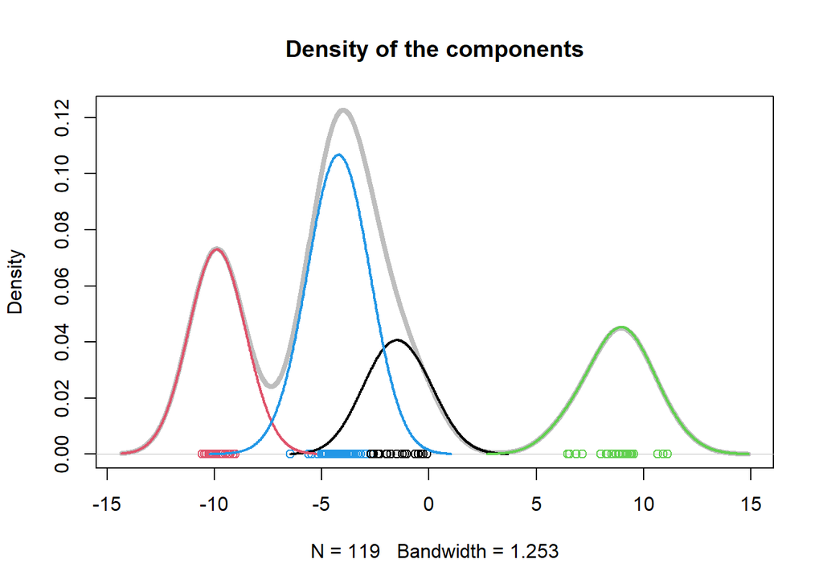

```r
C.2 <- round(jagsfit2.2$BUGSoutput$median$C)
mu.2 <- jagsfit2.2$BUGSoutput$median$mu
alpha.2 <- jagsfit2.2$BUGSoutput$median$alpha

plot.clusters.densities(y, C.2, alpha.2)
```

> - Suggest a way to compare the two models and propose a final model.

As an evaluation metric for the two models we can use the average silhouette coefficient.

Given the $i$-th observation, we define $a(i)$ as the average distance of $i$ from the other point in its cluster

$$a(i) = \frac{1}{N_{C_i}-1} \sum_{j \in C_i, i \ne j} |y_i-y_j|
\hspace{1cm} N_{C_i}= | \{\mbox{observations in componet } C_i \}|$$

and $b(i)$ as the average distance of $i$ from the points in the closest cluster

$$b(i) = \min_{J \ne C_i} \frac{1}{N_J} \sum_{C_j = J} |y_i-y_j|$$

The silhouette coefficient of $i$ is defined as

$$s(i) = \frac{b(i) - a(i)}{\max\{b(i), \, a(i)\}} \hspace{0.5cm} \mbox{if
}N_{C_i} > 1, \ \ 0 \mbox{ otherwise}$$
So $-1 \le s(i) \le 1$ and in general we say that observation $i$ is well classified if $s(i)$ is close to one.

Here is a function that computes the silhouette coefficients for a given clustering of the data.

```r
silhouette <- function(y, C, k){
  n <- length(y)
  a <- rep(NA, n)
  b <- rep(NA, n)
  s <- rep(0, n)
  for (i in 1:n){
    mask <- (C == C[i])
    if (sum(mask)>1){
      mask[i] <- FALSE
      a[i] <- mean( abs(y[i] - y[mask]) )

      J_ne_Ci <- as.matrix((1:k)[-C[i]])
      b[i] <- min(apply(J_ne_Ci, 1, function(j) mean(abs(y[i]-y[C==j])) ))
      s[i] <- (b[i] - a[i]) / max(a[i], b[i])
    }
  }
  return(s)
}
```

Looking at the histograms of the silhouette coefficients, we can see that in the second model some points are considered as missclassified and overall the clustering given by the first model looks better.

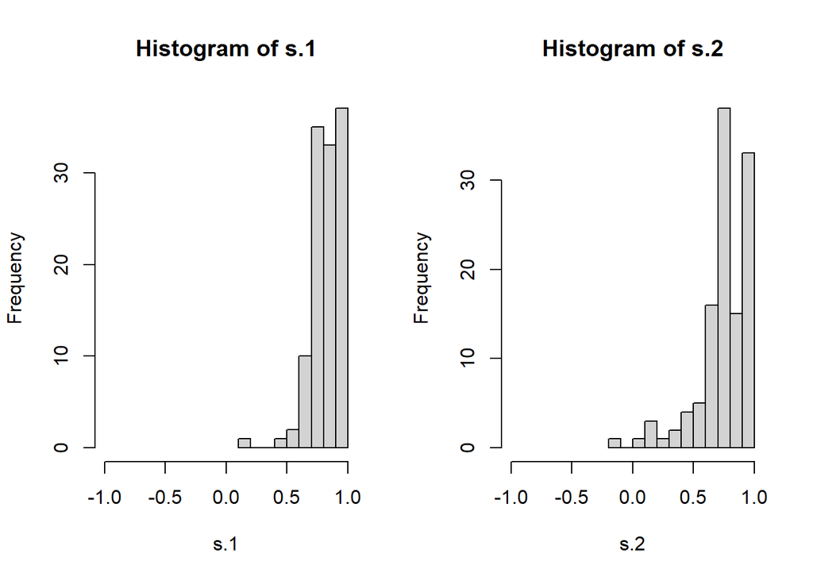

```r
s.1 <- silhouette(y, C.1, k=3)
s.2 <- silhouette(y, C.2, k=4)

par(mfrow=c(1, 2))
hist(s.1, xlim = c(-1, 1))
hist(s.2, xlim = c(-1, 1))
```

Even though we know that the true number of clusters is 4, the mean silhouette coefficients metric tells us that the clustering with $k=3$ is slightly better.

```r
colMeans(cbind(s.1, s.2))
```

```
##       s.1       s.2
## 0.8112138 0.7439111
```

> - Assume now the number of components is unknown. Implement in R a non parametric Gibbs sampler with stick-breaking approach and Dirichlet prior

As in previous exercise I use the blocked Gibbs sampler algorithm.

```r
Gibbs2.non_param <- function(n.iter, start, params, data, burn.in){
  y <- data
  n <- length(y)
  k <- params$k  # Maximum number of clusters
  beta <- params$beta

  C.seq <- matrix(NA, ncol=n, nrow=n.iter)
  mu.seq <- matrix(NA, ncol=k, nrow=n.iter)
  A.seq <- matrix(NA, ncol=k, nrow=n.iter)
  N_j.seq <- matrix(NA, ncol=k, nrow=n.iter)
  PI.seq <- matrix(NA, ncol=k, nrow=n.iter)

  C <- C.seq[1,] <- start$C
  mu <- mu.seq[1,] <- start$mu
  A <- A.seq[1,] <- start$A
  PI <- PI.seq[1,] <- start$PI
  N_j <- N_j.seq[1,] <- tabulate(C, k)

  for(l in 2:n.iter){
    # mu | alpha, A, Z
    y.plus_j <- apply(as.matrix(1:k), 1, function(j) sum(y[C==j]))
    mean.plus_j <- y.plus_j / N_j
    mean.plus_j[y.plus_j==0] <- 0
    delta_j <- N_j * A / (params$tau0 + N_j*A)
    mu <- rnorm(k, mean = delta_j * mean.plus_j + (1 - delta_j) * params$mu0,
                sd = sqrt(1 / (A * N_j + params$tau0)))

    # A | alpha, mu, Z
    SS_j <- apply(as.matrix(1:k), 1, function(j) sum( ((y - mu[j])^2)[C==j]) )
    A <- rgamma(k, shape=params$a + N_j/2,
                   rate=params$b + SS_j/2)

    # Z_i | p_i, PI, X_i
    for (i in 1:n){
      prob <- PI * dnorm(y[i], mu, 1 / sqrt(A))
      C[i] <- sample(1:k, 1, prob = prob)
    }
    # Update N_j
    N_j <- tabulate(C, k)

    # PI | Z_i
    stick.length <- 1
    for (j in 1:(k-1)){
      PI[j] <- stick.length * rbeta(1, params$alpha + N_j[j], params$beta + sum(N_j[-(1:j)]))
      stick.length <- stick.length - PI[j]
    }
    PI[k] <- 1 - sum(PI[1:(k-1)])

    C.seq[l,] <- C
    mu.seq[l,] <- mu
    A.seq[l,] <- A
    N_j.seq[l,] <- N_j
    PI.seq[l,] <- PI
  }

  result <- list(mu = mu.seq[-(1:burn.in),],
                 A = A.seq[-(1:burn.in),],
                 C = C.seq[-(1:burn.in),],
                 N_j = N_j.seq[-(1:burn.in),],
                 PI = PI.seq[-(1:burn.in),])
  return(result)
}
```

> - Run the non parametric Gibbs sampler for the above data and summarize your finding. In particular discuss the posterior distribution of the number of clusters

```r
k <- 20
y <- sort(y)
components <- rep(1:k, each=length(y)/k+1)[1:length(y)]
start <- list(PI = rep(1/k, k),
              mu = apply(as.matrix(1:k), 1, function(j) mean(y[components==j])),
              A = 1 / apply(as.matrix(1:k), 1, function(j) var(y[components==j])),
              C = components)

params <- list(c=rep(1, k),
               mu0 = mean(y),
               tau0 = 1 / 100,
               a = 1, b=1,
               alpha = 1, beta=1,
               k = k)

system.time(result <- Gibbs2.non_param(5000, start, params, data=y, burn.in = 1000))
```

```
##    utente   sistema trascorso
##      8.50      0.02      9.36
```

As before for each component we can estimate $\mu_j$, $\sigma^2_j$ and the number of points in each component.

```r
C <- apply(result$C, 2, median)
mu <- apply(result$mu, 2, median)
sigma2 <- 1 / apply(result$A, 2, median)

N_j <- apply(as.matrix(1:k), 1, function(j) sum(C==j))
rbind(mu[N_j>0], sigma2[N_j>0], N_j[N_j>0])
```

```
##            [,1]       [,2]      [,3]      [,4]
## [1,] -4.0977728 -9.8883792 -2.108508  8.603543
## [2,]  0.7981197  0.2536071  1.029154  1.370028
## [3,] 52.0000000 29.0000000 15.000000 23.000000
```

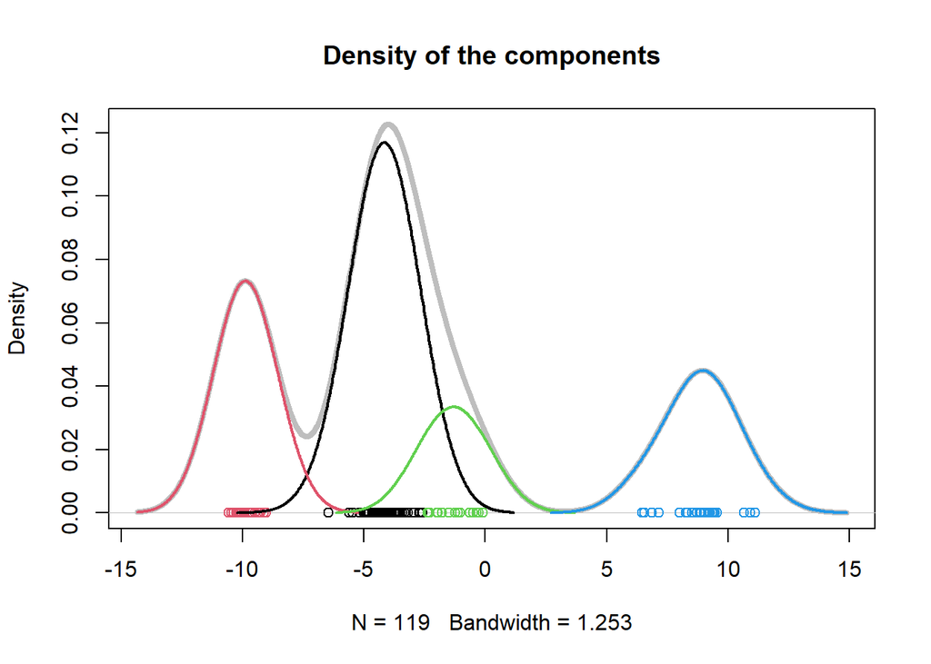

```r
plot.clusters.densities(y, C, N_j/length(y))
```

As in previous exercise, a lot of clusters have a small number of elements. Thus, it makes more sense to not consider the clusters with a small number of elements.

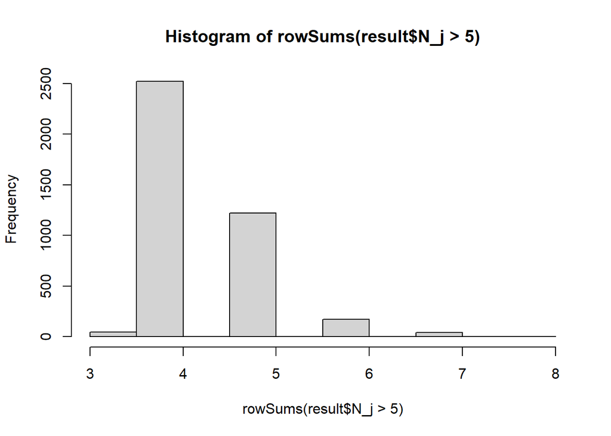

```r
hist(rowSums(result$N_j>5))
```

> - Compare the results with the previous analysis in which the number of components was fixed a priori

The distance between the two estimates of $\mu$ is small

```r
norm(sort(mu[N_j>0]) - sort(mu.2), "2")
```

```
## [1] 0.4739853
```

and also the mean silhoutte coefficient is very similar.

```r
s <- mean(silhouette(y, C, k=sum(N_j>0)))
mean(s)
```

```
## [1] 0.7445383
```

```r
mean(s) - mean(s.2)
```

```
## [1] 0.0006272241
```

This means that the result we obtain with the non-parametric approach is very similar to what we obtained assuming that $k=4$.